# IODS course project

Aleksandra Dobrego

# About the project

Hi! I’ve used R before, but the first week has been great to repeat some syntax. I do expect to learn **Markdown** since it has been in my to-do list for years. This course was recommended to me by my doctoral school.  
This is my project

# R Studio Exercise 2: Regression and model validation

*November 11, 2019*  
*This week I have performed a data wrangling on a dataset, analyzed and interpreted my regression model and did some nice plots.*

### **Looking at the dataset**

Reading a file and attaching the needed libraries (dplyr gives some little error but works fine):

```r
setwd("~/IODS-project/data")
library(ggplot2)
library("dplyr")
library(GGally)
my_learning <- read.table("learning2014.csv")
```

Exploring structure and dimensions:

```r
str(my_learning)
```

```
## 'data.frame':    166 obs. of  7 variables:
##  $ gender  : Factor w/ 2 levels "F","M": 1 2 1 2 2 1 2 1 2 1 ...
##  $ Age     : int  53 55 49 53 49 38 50 37 37 42 ...
##  $ Attitude: int  37 31 25 35 37 38 35 29 38 21 ...
##  $ deep    : num  3.58 2.92 3.5 3.5 3.67 ...
##  $ stra    : num  3.38 2.75 3.62 3.12 3.62 ...
##  $ surf    : num  2.58 3.17 2.25 2.25 2.83 ...
##  $ Points  : int  25 12 24 10 22 21 21 31 24 26 ...
```

We have numeric variables (deep = deep learning, stra = strategic learning, surf = surface learning), 3 integer variables (points, age, attitude) and 1 factor variable (gender).  
Lets also look at dimensions:

```r
dim(my_learning)
```

```
## [1] 166   7
```

The dataset has 166 observations and 7 variables.

### **Graphs**

Attitude and Points coloured by gender:

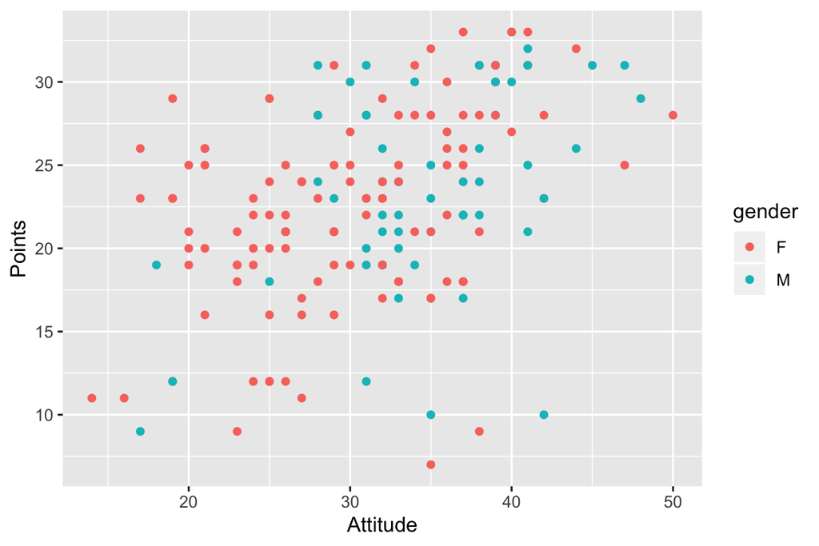

```r
ggplot(my_learning, aes(x = Attitude, y = Points, col = gender)) +
  geom_point()
```

Summaries of variables:

```r
summary(my_learning)
```

```
##  gender       Age           Attitude          deep            stra
##  F:110   Min.   :17.00   Min.   :14.00   Min.   :1.583   Min.   :1.250
##  M: 56   1st Qu.:21.00   1st Qu.:26.00   1st Qu.:3.333   1st Qu.:2.625
##          Median :22.00   Median :32.00   Median :3.667   Median :3.188
##          Mean   :25.51   Mean   :31.43   Mean   :3.680   Mean   :3.121
##          3rd Qu.:27.00   3rd Qu.:37.00   3rd Qu.:4.083   3rd Qu.:3.625
##          Max.   :55.00   Max.   :50.00   Max.   :4.917   Max.   :5.000
##       surf           Points
##  Min.   :1.583   Min.   : 7.00
##  1st Qu.:2.417   1st Qu.:19.00
##  Median :2.833   Median :23.00
##  Mean   :2.787   Mean   :22.72
##  3rd Qu.:3.167   3rd Qu.:27.75
##  Max.   :4.333   Max.   :33.00
```

Distribution of other variables:  
**Age**

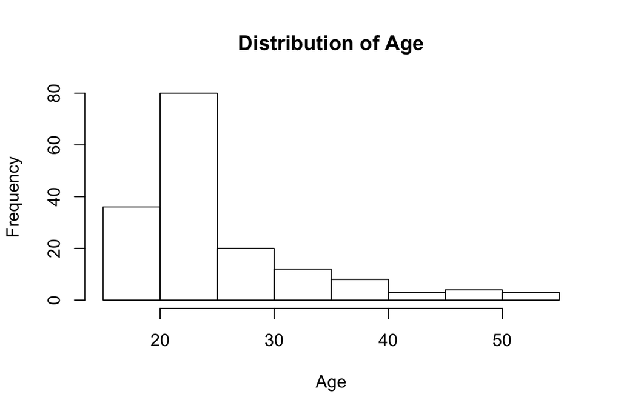

```r
hist(my_learning$Age, xlab = "Age", main = "Distribution of Age")
```

Distribution of age is not normal.

**Attitude**

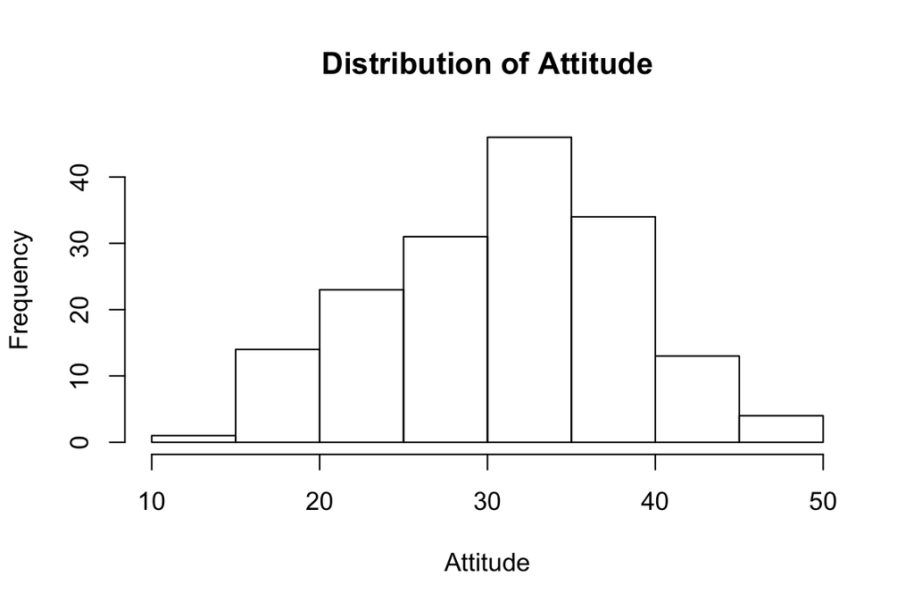

```r
hist(my_learning$Attitude, xlab = "Attitude", main = "Distribution of Attitude")
```

Distribution of attitude is normal.

**Deep learning**

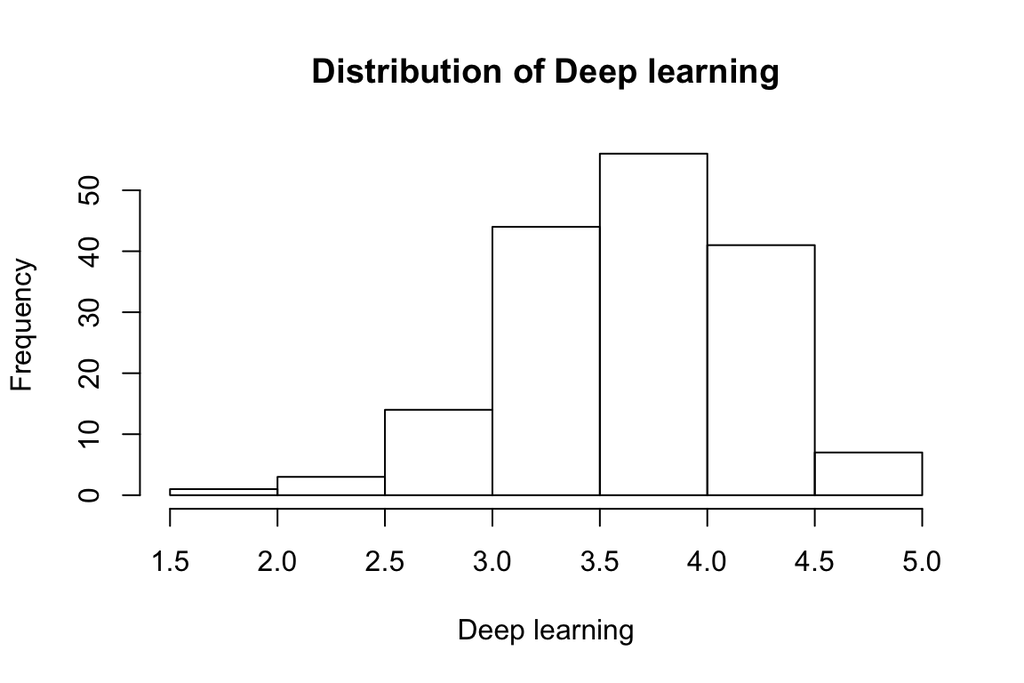

```r
hist(my_learning$deep, xlab = "Deep learning", main = "Distribution of Deep learning")
```

Distribution of deep learning is normal.

**Strategic learning**

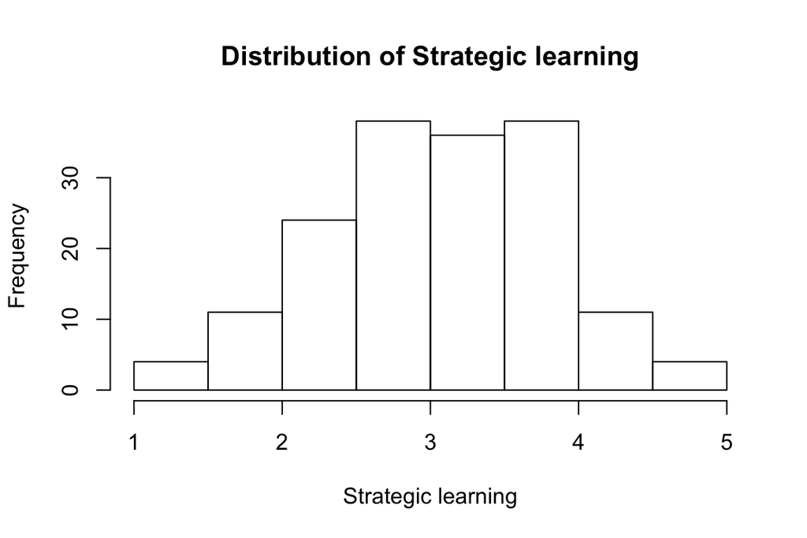

```r
hist(my_learning$stra, xlab = "Strategic learning", main = "Distribution of Strategic learning")
```

**Surface learning**

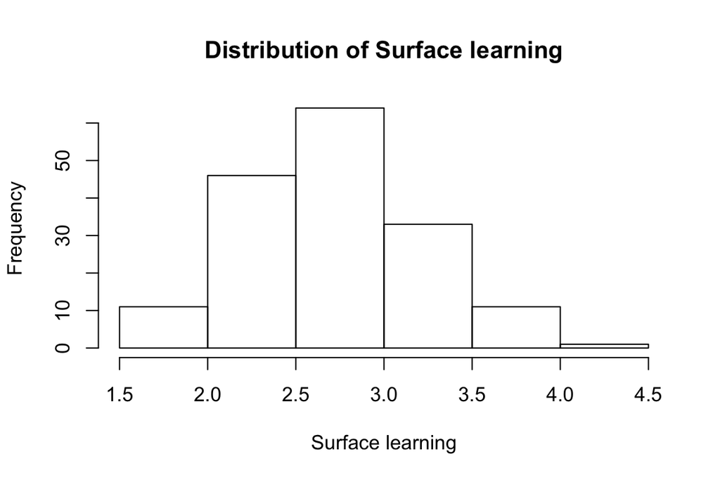

```r
hist(my_learning$surf, xlab = "Surface learning", main = "Distribution of Surface learning")
```

Distribution of surface learning is normal.

**Points**

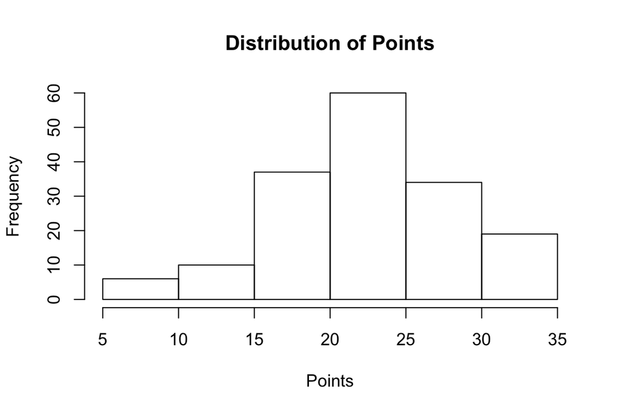

```r
hist(my_learning$Points, xlab = "Points", main = "Distribution of Points")
```

Distribution of points is normal.

Now lets see relationship between variables:

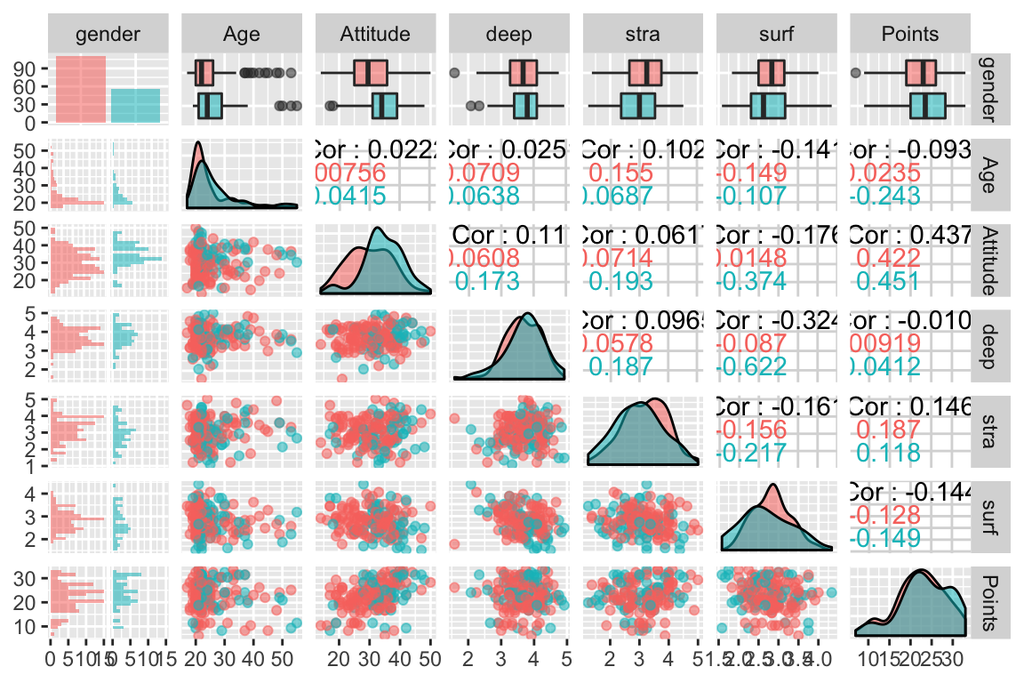

```r
ggpairs(my_learning, mapping = aes(col = gender, alpha = 0.3), lower = list(combo = wrap("facethist", bins = 20)))
```

**Conclusion on variables**: correlation is actually very low for all variables, but the highest is for attitude&points.

### **Regression model**

Now I do multiple regression model with attutude, strategic questions and deep learning questions; exam points is a dependent variable:

```r
model <- lm(Points ~ Attitude + stra + deep, data = my_learning)
```

Summary of the model:

```r
summary(model)
```

```
##
## Call:
## lm(formula = Points ~ Attitude + stra + deep, data = my_learning)
##
## Residuals:
##      Min       1Q   Median       3Q      Max
## -17.5239  -3.4276   0.5474   3.8220  11.5112
##
## Coefficients:
##             Estimate Std. Error t value Pr(>|t|)
## (Intercept) 11.39145    3.40775   3.343  0.00103 **
## Attitude     0.35254    0.05683   6.203 4.44e-09 ***
## stra         0.96208    0.53668   1.793  0.07489 .
## deep        -0.74920    0.75066  -0.998  0.31974
## ---
## Signif. codes:  0 '***' 0.001 '**' 0.01 '*' 0.05 '.' 0.1 ' ' 1
##
## Residual standard error: 5.289 on 162 degrees of freedom
## Multiple R-squared:  0.2097, Adjusted R-squared:  0.195
## F-statistic: 14.33 on 3 and 162 DF,  p-value: 2.521e-08
```

Interpretation of model results and stats:  
1. P value is very low, which means that, at least, one of the predictor variables is significantly related to the outcome variable;  
2. Only attitude can explain points well, that is, **changes in attitude will affect points**.

As others are not significating, we can remove them from the model:

```r
modelnostranodeep <- lm(Points ~ Attitude, data = my_learning)
summary(modelnostranodeep)
```

```
##
## Call:
## lm(formula = Points ~ Attitude, data = my_learning)
##
## Residuals:
##      Min       1Q   Median       3Q      Max
## -16.9763  -3.2119   0.4339   4.1534  10.6645
##
## Coefficients:
##             Estimate Std. Error t value Pr(>|t|)
## (Intercept) 11.63715    1.83035   6.358 1.95e-09 ***
## Attitude     0.35255    0.05674   6.214 4.12e-09 ***
## ---
## Signif. codes:  0 '***' 0.001 '**' 0.01 '*' 0.05 '.' 0.1 ' ' 1
##
## Residual standard error: 5.32 on 164 degrees of freedom
## Multiple R-squared:  0.1906, Adjusted R-squared:  0.1856
## F-statistic: 38.61 on 1 and 164 DF,  p-value: 4.119e-09
```

I am going back to the original model:

```r
model <- lm(Points ~ Attitude + stra + deep, data = my_learning)
summary(model)
```

```
##
## Call:
## lm(formula = Points ~ Attitude + stra + deep, data = my_learning)
##
## Residuals:
##      Min       1Q   Median       3Q      Max
## -17.5239  -3.4276   0.5474   3.8220  11.5112
##
## Coefficients:
##             Estimate Std. Error t value Pr(>|t|)
## (Intercept) 11.39145    3.40775   3.343  0.00103 **
## Attitude     0.35254    0.05683   6.203 4.44e-09 ***
## stra         0.96208    0.53668   1.793  0.07489 .
## deep        -0.74920    0.75066  -0.998  0.31974
## ---
## Signif. codes:  0 '***' 0.001 '**' 0.01 '*' 0.05 '.' 0.1 ' ' 1
##
## Residual standard error: 5.289 on 162 degrees of freedom
## Multiple R-squared:  0.2097, Adjusted R-squared:  0.195
## F-statistic: 14.33 on 3 and 162 DF,  p-value: 2.521e-08
```

Relationship between variables and the target: only changes in attitude affect the exam points.  
**R = 0.2097, which means that only 20% of of the variance in the points can be explained by chosen variables.**

### **Model plots**

So our model is:

```r
model <- lm(Points ~ Attitude + stra + deep, data = my_learning)
```

First, plot of **Residuals vs Fitted Values**: used to explore whether errors depend on explanatory variables:

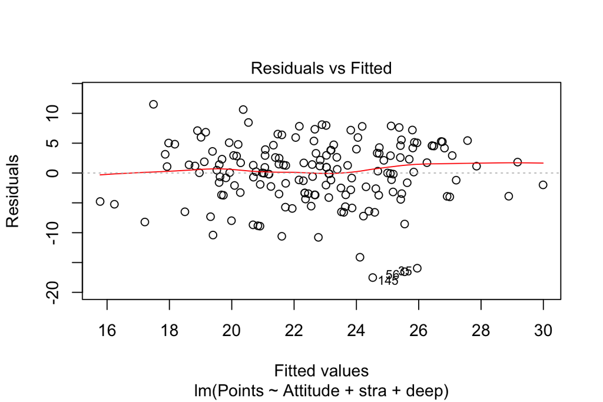

```r
plot(model, which = c(1))
```

Result: our plot looks reasonable.

Second, **Normal QQplot**: used to explore whether the errors are normally distributed:

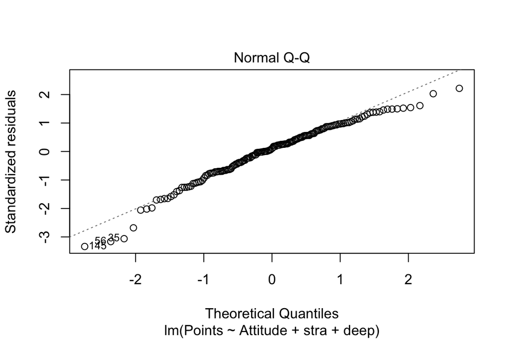

```r
plot(model, which = c(2))
```

Result: our QQplot looks reasonable.

Third, plot of **Residuals vs Leverage**: identifies which observations have unusually high impact on the model:

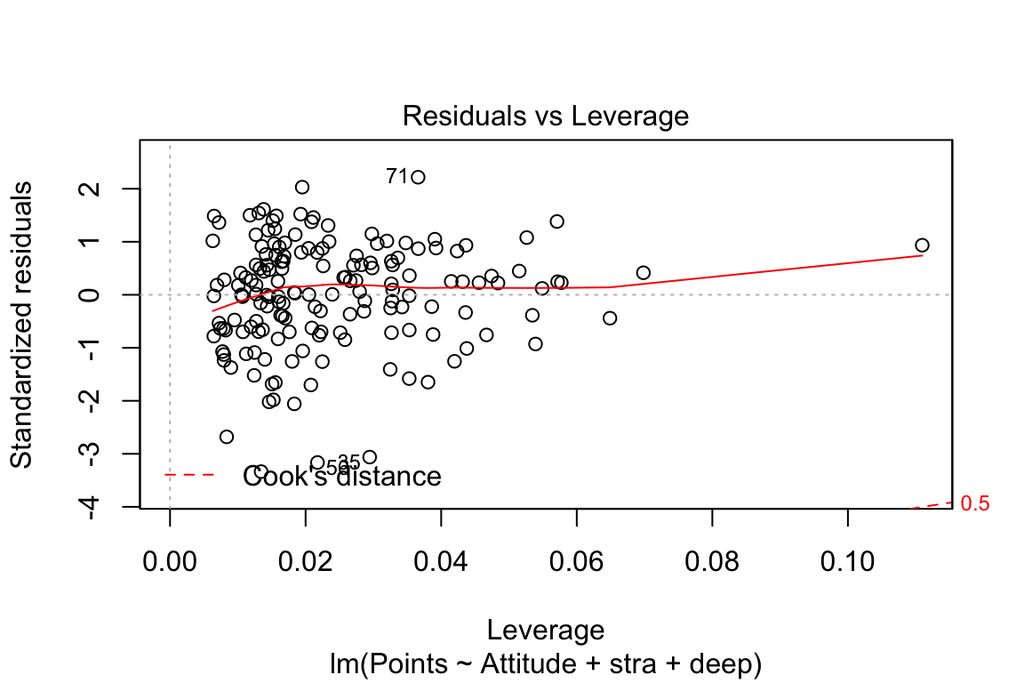

```r
plot(model, which = c(5))
```

**Conclusion: we should remove outliers.**

# R Studio Exercise 3: Logistic regression

*November 13, 2019*  
*This week I have performed a data wrangling on a joined dataset and did logistic regression.*

### **Our dataset**

Reading a file and attaching the needed libraries (dplyr gives some little error but works fine):

```r
setwd("~/IODS-project/data")
library(ggplot2)
library(dplyr)
library(boot)
joineddata <- read.table("joineddata.csv")
```

Printing out variable names:

```r
colnames(joineddata)
```

```
##  [1] "school"     "sex"        "age"        "address"    "famsize"
##  [6] "Pstatus"    "Medu"       "Fedu"       "Mjob"       "Fjob"
## [11] "reason"     "nursery"    "internet"   "guardian"   "traveltime"
## [16] "studytime"  "failures"   "schoolsup"  "famsup"     "paid"
## [21] "activities" "higher"     "romantic"   "famrel"     "freetime"
## [26] "goout"      "Dalc"       "Walc"       "health"     "absences"
## [31] "G1"         "G2"         "G3"         "alc_use"    "high_use"
```

This is data from two questionnaires related to student performance (including alcohol consumption).  
The dataset consists of 382 observations (rows) and 35 variables (columns).

### **Lets hypothesise**

1. Alcohol consumption and **gender** are related: males consume more alcohol, than females.
2. Alcohol consumption and **first period grade** are related: greater first grade means less alcohol consumption for both genders.
3. Alcohol consumption and **second period grade** are related: greater second grade means less alcohol consumption for both genders.
4. Alcohol consumption and **third period grade** are related: greater third grade means less alcohol consumption for both genders.

### **Exploring the variables**

Before looking at variables, lets look at the alcohol consumption distribution:

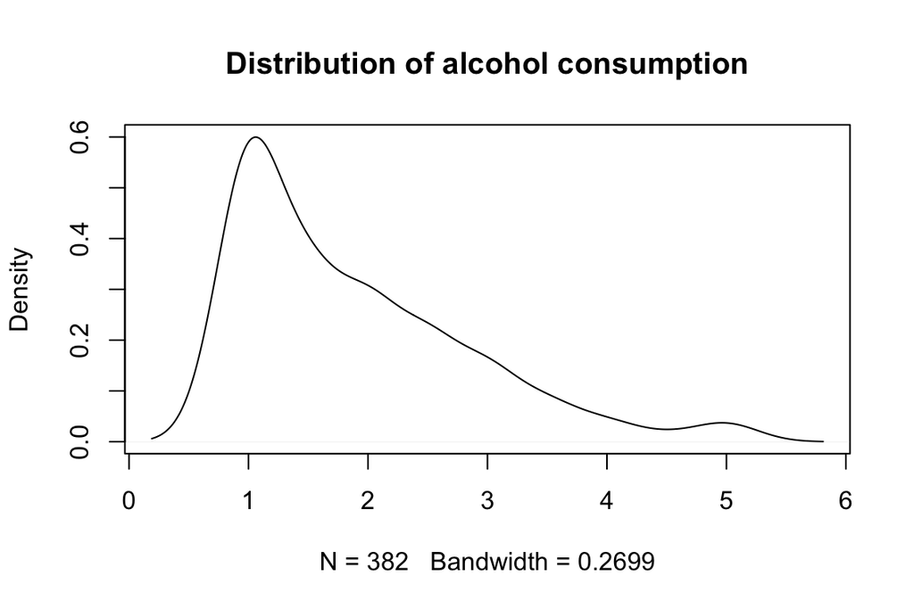

```r
plot(density(joineddata$alc_use), main = "Distribution of alcohol consumption")
```

We can see that the consumption is mostly low across all dataframe.

Now lets do some numerical exploration:

**Gender**

```r
summary(joineddata$sex)
```

```
##   F   M
## 198 184
```

We can see relatively equal amount of males and females.

**First period grades**

```r
summary(joineddata$G1)
```

```
##    Min. 1st Qu.  Median    Mean 3rd Qu.    Max.
##    2.00   10.00   12.00   11.49   14.00   18.00
```

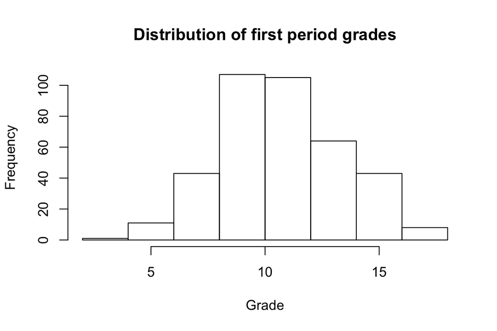

```r
hist(joineddata$G1, main = "Distribution of first period grades", xlab = "Grade")
```

Distribution of first period grades is normal.

**Second period grades**

```r
summary(joineddata$G2)
```

```
##    Min. 1st Qu.  Median    Mean 3rd Qu.    Max.
##    4.00   10.00   12.00   11.47   14.00   18.00
```

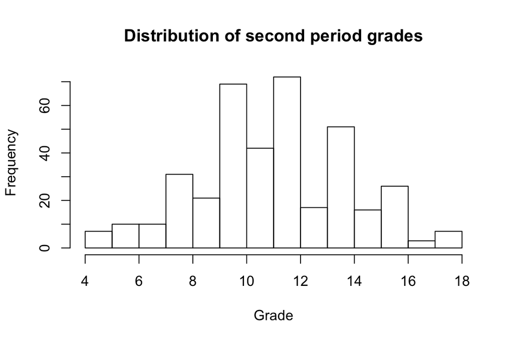

```r
hist(joineddata$G2, main = "Distribution of second period grades", xlab = "Grade")
```

Distribution of second period grades is normal.

**Final grades**

```r
summary(joineddata$G3)
```

```
##    Min. 1st Qu.  Median    Mean 3rd Qu.    Max.
##    0.00   10.00   12.00   11.46   14.00   18.00
```

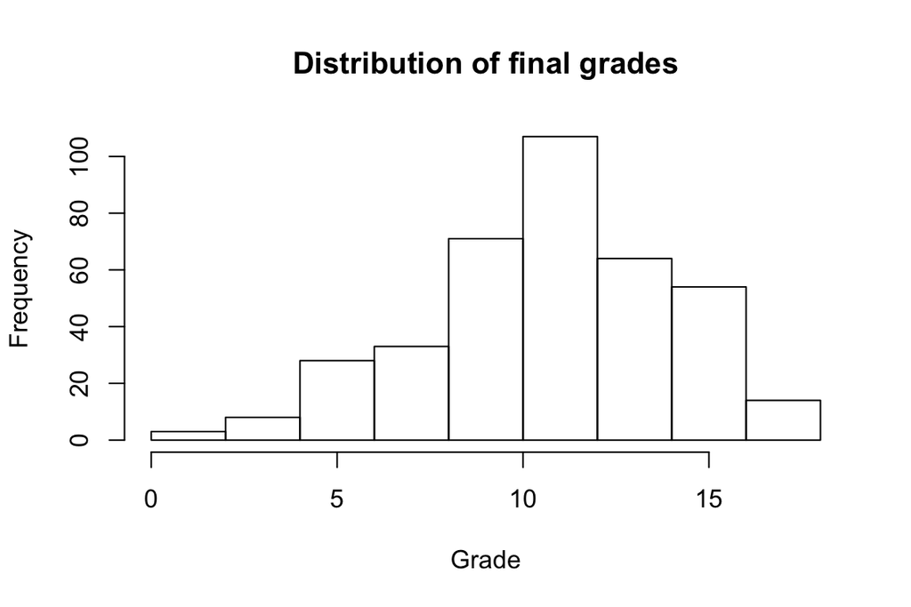

```r
hist(joineddata$G3, main = "Distribution of final grades", xlab = "Grade")
```

Distribution of final grades is normal.

Now it’s time for graphical exploration:

**Hypothesis 1**: males consume more alcohol, than females.

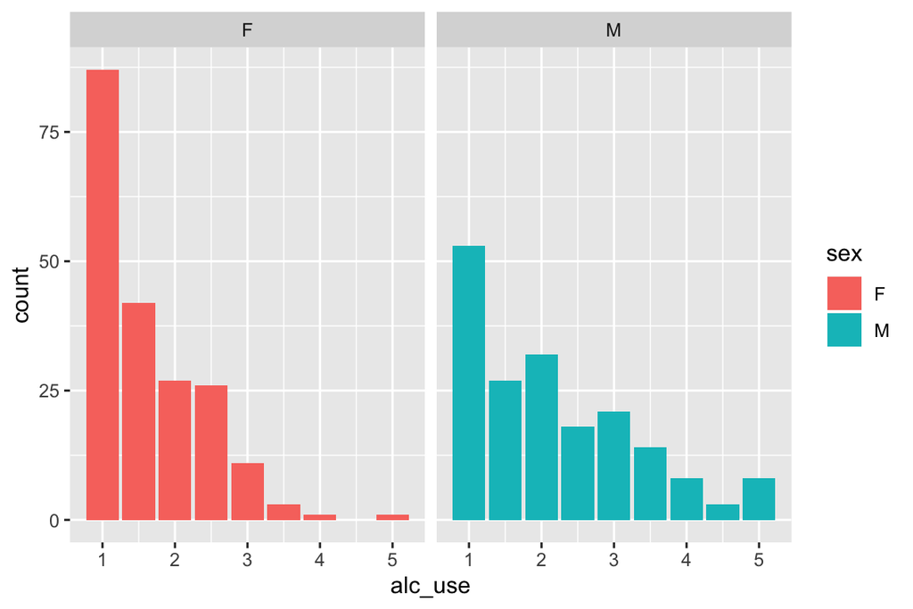

```r
g1 <- ggplot(data = joineddata, aes(x = alc_use, fill = sex))
g1 + geom_bar() + facet_wrap("sex")
```

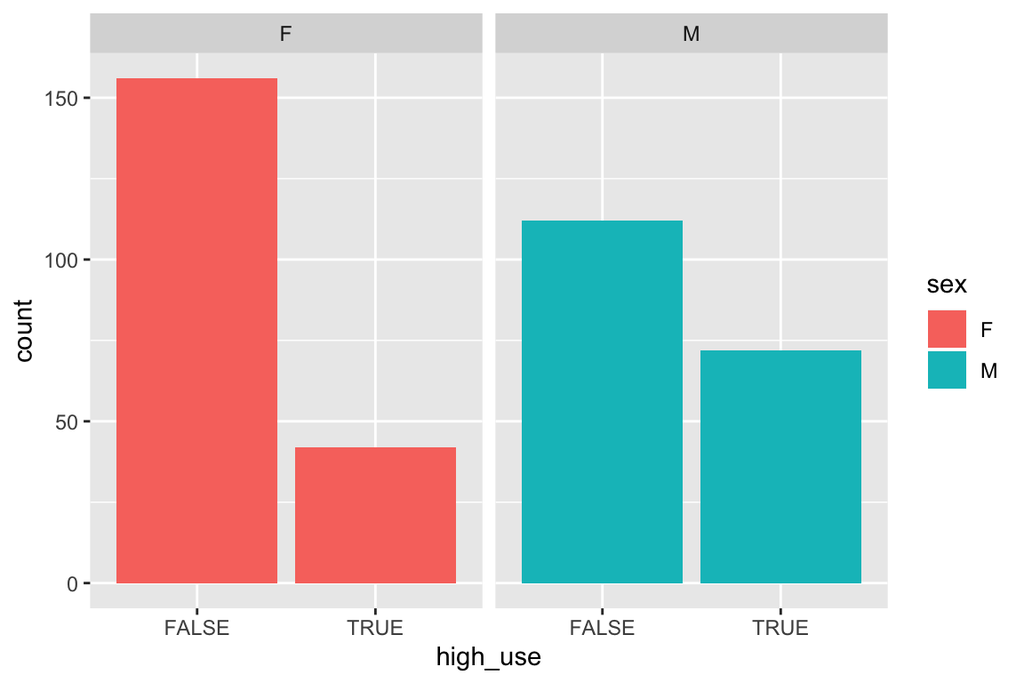

```r
g1 <- ggplot(data = joineddata, aes(x = high_use, fill = sex))
g1 + geom_bar() + facet_wrap("sex")
```

This bar graph confirms the previous explanation, women don’t consume much.  
**Conclusion**: my hypothesis can be partly confirmed.

**Hypothesis 2**: greater first grade means less alcohol consumption for both genders.

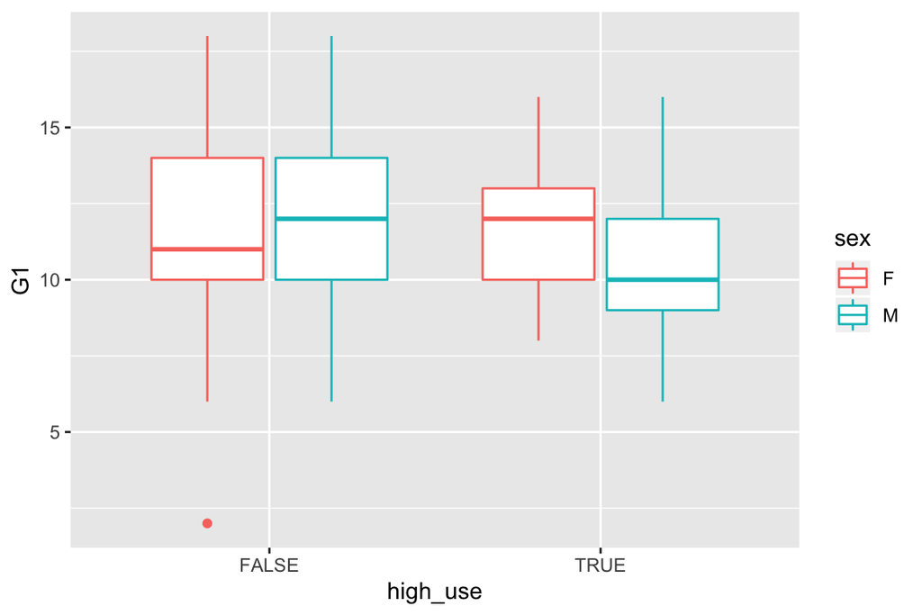

```r
g3 <- ggplot(joineddata, aes(x = high_use, y = G1, col = sex))
g3 + geom_boxplot()
```

There is no difference between girls whose consumption is high or low.  
However, boys who consume more have lower grades.  
**Conclusion**: my hypothesis can be partly confirmed (for boys).

**Hypothesis 3**: greater second grade means less alcohol consumption for both genders.

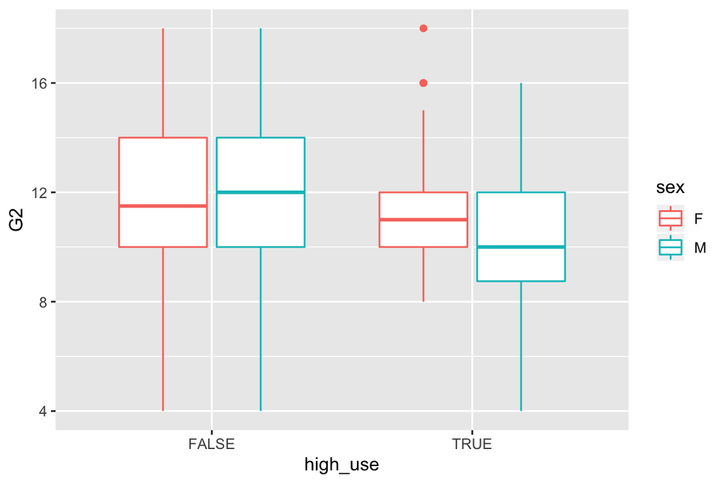

```r
g4 <- ggplot(joineddata, aes(x = high_use, y = G2, col = sex))
g4 + geom_boxplot()
```

Visually there is almost no difference between girls, but it may change after removing an outlier.  
Visually, boys who consume more have lower grades.  
**Conclusion**: my hypothesis can be partly confirmed (for boys).

**Hypothesis 4**: greater final grade means less alcohol consumption for both genders.

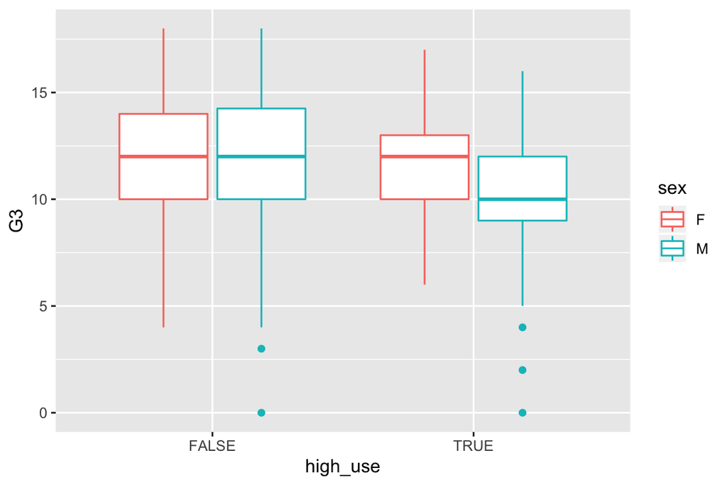

```r
g5 <- ggplot(joineddata, aes(x = high_use, y = G3, col = sex))
g5 + geom_boxplot()
```

### **Logistic regression**

```r
m <- glm(high_use ~ sex + G1 + G2 + G3, data = joineddata, family = "binomial")
summary(m)
```

```
##
## Call:
## glm(formula = high_use ~ sex + G1 + G2 + G3, family = "binomial",
##     data = joineddata)
##
## Deviance Residuals:
##     Min       1Q   Median       3Q      Max
## -1.2828  -0.8657  -0.6845   1.2340   2.0382
##
## Coefficients:
##              Estimate Std. Error z value Pr(>|z|)
## (Intercept)  0.140881   0.530729   0.265 0.790664
## sexM         0.883365   0.233216   3.788 0.000152 ***
## G1          -0.120940   0.094241  -1.283 0.199385
## G2          -0.010811   0.116916  -0.092 0.926328
## G3           0.002673   0.086031   0.031 0.975211
## ---
## Signif. codes:  0 '***' 0.001 '**' 0.01 '*' 0.05 '.' 0.1 ' ' 1
##
## (Dispersion parameter for binomial family taken to be 1)
##
##     Null deviance: 465.68  on 381  degrees of freedom
## Residual deviance: 442.10  on 377  degrees of freedom
## AIC: 452.1
##
## Number of Fisher Scoring iterations: 4
```

Lets look at model’s coefficients:

```r
coef(m)
```

```
## (Intercept)        sexM          G1          G2          G3
##  0.14088116  0.88336501 -0.12093983 -0.01081064  0.00267323
```

And odds ratios:

```r
OR <- coef(m) %>% exp
OR
```

```
## (Intercept)        sexM          G1          G2          G3
##   1.1512878   2.4190261   0.8860873   0.9892476   1.0026768
```

And confidence intervals:

```r
CI <- confint(m) %>% exp
CI
```

```
##                 2.5 %   97.5 %
## (Intercept) 0.4066194 3.274532
## sexM        1.5383105 3.843873
## G1          0.7350499 1.065697
## G2          0.7864414 1.246077
## G3          0.8475937 1.190283
```

Now lets look at all them:

```r
cbind(OR, CI)
```

```
##                    OR     2.5 %   97.5 %
## (Intercept) 1.1512878 0.4066194 3.274532
## sexM        2.4190261 1.5383105 3.843873
## G1          0.8860873 0.7350499 1.065697
## G2          0.9892476 0.7864414 1.246077
## G3          1.0026768 0.8475937 1.190283
```

### **Predictive power**

I am only using the “sex” and the “G3” now.

```r
m <- glm(high_use ~ sex + G3, data = joineddata, family = "binomial")
summary(m)
```

```
##
## Call:
## glm(formula = high_use ~ sex + G3, family = "binomial", data = joineddata)
##
## Deviance Residuals:
##     Min       1Q   Median       3Q      Max
## -1.4158  -0.8453  -0.6698   1.2796   1.9827
##
## Coefficients:
##             Estimate Std. Error z value Pr(>|z|)
## (Intercept) -0.33776    0.41861  -0.807 0.419757
## sexM         0.88254    0.23246   3.796 0.000147 ***
## G3          -0.08688    0.03466  -2.507 0.012189 *
## ---
## Signif. codes:  0 '***' 0.001 '**' 0.01 '*' 0.05 '.' 0.1 ' ' 1
##
## (Dispersion parameter for binomial family taken to be 1)
##
##     Null deviance: 465.68  on 381  degrees of freedom
## Residual deviance: 444.55  on 379  degrees of freedom
## AIC: 450.55
##
## Number of Fisher Scoring iterations: 4
```

Both variables are significant.

```r
probabilities <- predict(m, type = "response")
joineddata <- mutate(joineddata, probability = probabilities)
joineddata <- mutate(joineddata, prediction = probability > 0.5)
select(joineddata, sex, G3, high_use, probability, prediction) %>% tail(10)
```

```
##     sex G3 high_use probability prediction
## 373   M  0    FALSE   0.6329243       TRUE
## 374   M  2     TRUE   0.5917072       TRUE
## 375   F 12    FALSE   0.2009626      FALSE
## 376   F  8    FALSE   0.2625459      FALSE
## 377   F  5    FALSE   0.3160153      FALSE
## 378   F 12    FALSE   0.2009626      FALSE
## 379   F  4    FALSE   0.3350868      FALSE
## 380   F  4    FALSE   0.3350868      FALSE
## 381   M 13     TRUE   0.3578685      FALSE
## 382   M 10     TRUE   0.4197026      FALSE
```

Now lets do 2x2 cross tabulation:

```r
table(high_use = joineddata$high_use, prediction = joineddata$prediction)
```

```
##         prediction
## high_use FALSE TRUE
##    FALSE   258   10
##    TRUE    104   10
```

And graphic representation:

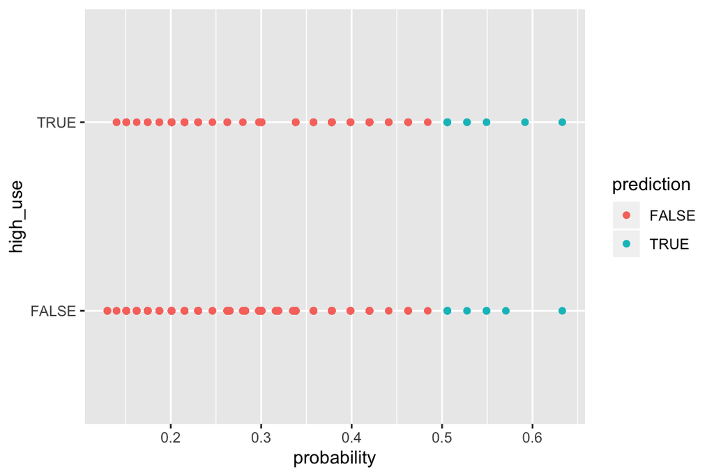

```r
g <- ggplot(joineddata, aes(x = probability, y = high_use, col = prediction))
g + geom_point()
```

Now we can explore the training error:

```r
loss_func <- function(class, prob) {
  n_wrong <- abs(class - prob) > 0.5
  mean(n_wrong)
}
loss_func(class = joineddata$high_use, prob = joineddata$probability)
```

```
## [1] 0.2984293
```

Proportion of incorrect predictions (training error) is almost 30%.

### **BONUS: 10-fold cross-validation**

```r
cv <- cv.glm(data = joineddata, cost = loss_func, glmfit = m, K = 10)
cv$delta[1]
```

```
## [1] 0.3010471
```

The prediction error is 0.30 - it’s a bit worse than DataCamp’s model error.

# R Studio Exercise 4: Clustering and classification

*November 22, 2019*  
*This week I worked with Boston dataset.*

### **Playing with the dataset**

**Loading** the Boston data and exploring the structure and dimensions:

```r
library(MASS)
data('Boston')
str(Boston)
```

```
## 'data.frame':    506 obs. of  14 variables:
##  $ crim   : num  0.00632 0.02731 0.02729 0.03237 0.06905 ...
##  $ zn     : num  18 0 0 0 0 0 12.5 12.5 12.5 12.5 ...
##  $ indus  : num  2.31 7.07 7.07 2.18 2.18 2.18 7.87 7.87 7.87 7.87 ...
##  $ chas   : int  0 0 0 0 0 0 0 0 0 0 ...
##  $ nox    : num  0.538 0.469 0.469 0.458 0.458 0.458 0.524 0.524 0.524 0.524 ...
##  $ rm     : num  6.58 6.42 7.18 7 7.15 ...
##  $ age    : num  65.2 78.9 61.1 45.8 54.2 58.7 66.6 96.1 100 85.9 ...
##  $ dis    : num  4.09 4.97 4.97 6.06 6.06 ...
##  $ rad    : int  1 2 2 3 3 3 5 5 5 5 ...
##  $ tax    : num  296 242 242 222 222 222 311 311 311 311 ...
##  $ ptratio: num  15.3 17.8 17.8 18.7 18.7 18.7 15.2 15.2 15.2 15.2 ...
##  $ black  : num  397 397 393 395 397 ...
##  $ lstat  : num  4.98 9.14 4.03 2.94 5.33 ...
##  $ medv   : num  24 21.6 34.7 33.4 36.2 28.7 22.9 27.1 16.5 18.9 ...
```

```r
dim(Boston)
```

```
## [1] 506  14
```

This dataset contains information collected by the U.S Census Service concerning housing in the area of Boston Mass.  
It has 506 observations (rows) and 14 variables (columns).

**Graphical overview** of the data:

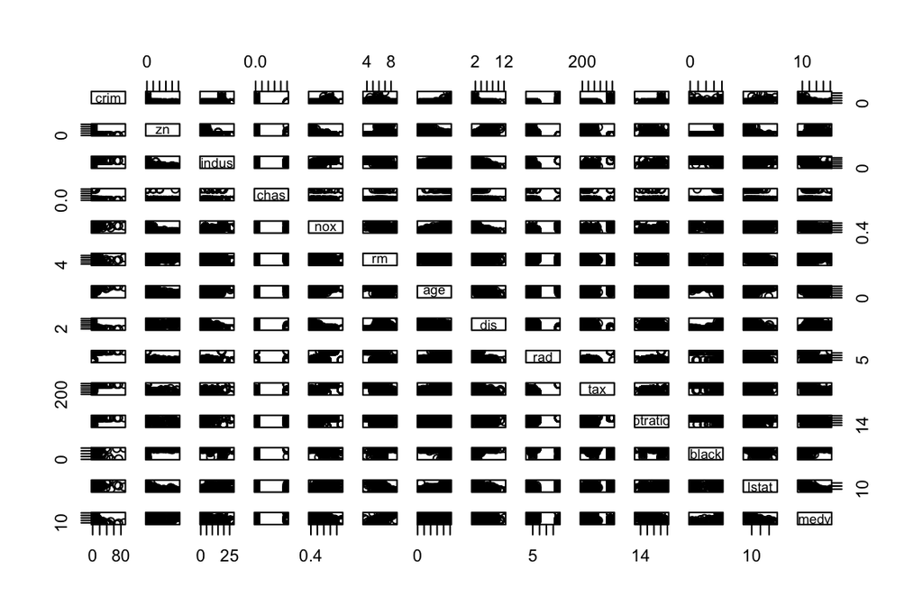

```r
pairs(Boston)
```

We can see scatterplots of the relationships of data’s variables.  
What we are looking here are any linear or U-shaped patterns, that might tell us about some dependancies. For instance, we can see some correlation patterns between “nox” and “dis”, “lstat” and “medv”, “lstat” and “rm”, “medv” and “rm”.  
*nox - nitric oxides concentration*  
*dis - weighted distances to five Boston employment centres*  
*lstat - % lower status of the population*  
*medv - median value of owner-occupied homes in $1000’s*  
*rm - average number of rooms per dwelling*

**Summaries** of the variables:

```r
summary(Boston)
```

```
##       crim                zn             indus            chas
##  Min.   : 0.00632   Min.   :  0.00   Min.   : 0.46   Min.   :0.00000
##  1st Qu.: 0.08204   1st Qu.:  0.00   1st Qu.: 5.19   1st Qu.:0.00000
##  Median : 0.25651   Median :  0.00   Median : 9.69   Median :0.00000
##  Mean   : 3.61352   Mean   : 11.36   Mean   :11.14   Mean   :0.06917
##  3rd Qu.: 3.67708   3rd Qu.: 12.50   3rd Qu.:18.10   3rd Qu.:0.00000
##  Max.   :88.97620   Max.   :100.00   Max.   :27.74   Max.   :1.00000
##       nox               rm             age              dis
##  Min.   :0.3850   Min.   :3.561   Min.   :  2.90   Min.   : 1.130
##  1st Qu.:0.4490   1st Qu.:5.886   1st Qu.: 45.02   1st Qu.: 2.100
##  Median :0.5380   Median :6.208   Median : 77.50   Median : 3.207
##  Mean   :0.5547   Mean   :6.285   Mean   : 68.57   Mean   : 3.795
##  3rd Qu.:0.6240   3rd Qu.:6.623   3rd Qu.: 94.08   3rd Qu.: 5.188
##  Max.   :0.8710   Max.   :8.780   Max.   :100.00   Max.   :12.127
##       rad              tax           ptratio          black
##  Min.   : 1.000   Min.   :187.0   Min.   :12.60   Min.   :  0.32
##  1st Qu.: 4.000   1st Qu.:279.0   1st Qu.:17.40   1st Qu.:375.38
##  Median : 5.000   Median :330.0   Median :19.05   Median :391.44
##  Mean   : 9.549   Mean   :408.2   Mean   :18.46   Mean   :356.67
##  3rd Qu.:24.000   3rd Qu.:666.0   3rd Qu.:20.20   3rd Qu.:396.23
##  Max.   :24.000   Max.   :711.0   Max.   :22.00   Max.   :396.90
##      lstat            medv
##  Min.   : 1.73   Min.   : 5.00
##  1st Qu.: 6.95   1st Qu.:17.02
##  Median :11.36   Median :21.20
##  Mean   :12.65   Mean   :22.53
##  3rd Qu.:16.95   3rd Qu.:25.00
##  Max.   :37.97   Max.   :50.00
```

We can see that the “chas” variable looks very weird, but it is due to it being integer (0 and 1).  
Also, the “black” variable clearly has an outlier.  
*chas - Charles River dummy variable (1 if tract bounds river; 0 otherwise)*  
*black - proportion of blacks by town*

**Scaling** the dataset:

```r
boston_scaled <- scale(Boston)
summary(boston_scaled)
```

```
##       crim                 zn               indus
##  Min.   :-0.419367   Min.   :-0.48724   Min.   :-1.5563
##  1st Qu.:-0.410563   1st Qu.:-0.48724   1st Qu.:-0.8668
##  Median :-0.390280   Median :-0.48724   Median :-0.2109
##  Mean   : 0.000000   Mean   : 0.00000   Mean   : 0.0000
##  3rd Qu.: 0.007389   3rd Qu.: 0.04872   3rd Qu.: 1.0150
##  Max.   : 9.924110   Max.   : 3.80047   Max.   : 2.4202
##       chas              nox                rm               age
##  Min.   :-0.2723   Min.   :-1.4644   Min.   :-3.8764   Min.   :-2.3331
##  1st Qu.:-0.2723   1st Qu.:-0.9121   1st Qu.:-0.5681   1st Qu.:-0.8366
##  Median :-0.2723   Median :-0.1441   Median :-0.1084   Median : 0.3171
##  Mean   : 0.0000   Mean   : 0.0000   Mean   : 0.0000   Mean   : 0.0000
##  3rd Qu.:-0.2723   3rd Qu.: 0.5981   3rd Qu.: 0.4823   3rd Qu.: 0.9059
##  Max.   : 3.6648   Max.   : 2.7296   Max.   : 3.5515   Max.   : 1.1164
##       dis               rad               tax             ptratio
##  Min.   :-1.2658   Min.   :-0.9819   Min.   :-1.3127   Min.   :-2.7047
##  1st Qu.:-0.8049   1st Qu.:-0.6373   1st Qu.:-0.7668   1st Qu.:-0.4876
##  Median :-0.2790   Median :-0.5225   Median :-0.4642   Median : 0.2746
##  Mean   : 0.0000   Mean   : 0.0000   Mean   : 0.0000   Mean   : 0.0000
##  3rd Qu.: 0.6617   3rd Qu.: 1.6596   3rd Qu.: 1.5294   3rd Qu.: 0.8058
##  Max.   : 3.9566   Max.   : 1.6596   Max.   : 1.7964   Max.   : 1.6372
##      black             lstat              medv
##  Min.   :-3.9033   Min.   :-1.5296   Min.   :-1.9063
##  1st Qu.: 0.2049   1st Qu.:-0.7986   1st Qu.:-0.5989
##  Median : 0.3808   Median :-0.1811   Median :-0.1449
##  Mean   : 0.0000   Mean   : 0.0000   Mean   : 0.0000
##  3rd Qu.: 0.4332   3rd Qu.: 0.6024   3rd Qu.: 0.2683
##  Max.   : 0.4406   Max.   : 3.5453   Max.   : 2.9865
```

```r
boston_scaled <- as.data.frame(boston_scaled) #making our object a dataframe
```

The variables changed. We subtracted the column means from the corresponding columns and divided the difference with standard deviation. Now all variables means are zeros.

**Creating a categorical variable:**

```r
bins <- quantile(boston_scaled$crim) #using the quantiles as the break points
crime <- cut(boston_scaled$crim, breaks = bins, include.lowest = TRUE, label = c("low", "med_low", "med_high", "high")) #creating a variable
boston_scaled <- dplyr::select(boston_scaled, -crim) #dropping the old crime variable
boston_scaled <- data.frame(boston_scaled, crime) #adding the new crime variable to the dataset
```

Now lets divide the dataset to **train** and **test** ones:

```r
n <- nrow(boston_scaled) #number of rows
ind <- sample(n,  size = n * 0.8) #random choice of 80% of rows
train <- boston_scaled[ind,] #train set
test <- boston_scaled[-ind,] #test set
```

### **Linear Discriminant Analysis**

Lets **fit the LDA** on the train set:

```r
lda.fit <- lda(crime ~ ., data = train) #crime is a target variable and all others are predictors
```

**(Bi)Plotting the LDA**:

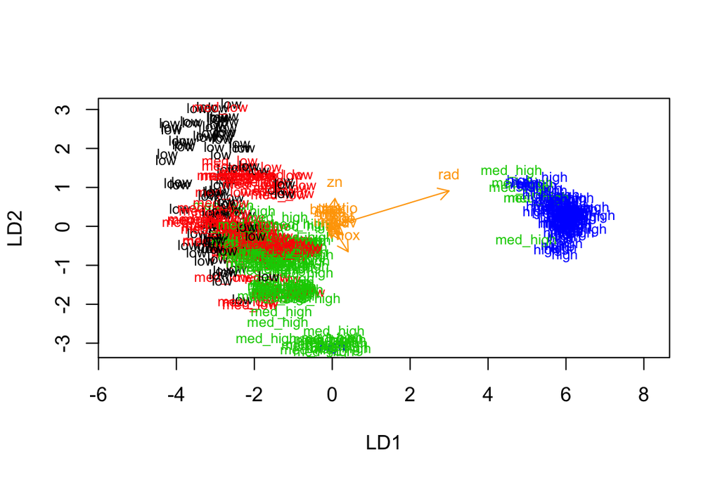

```r
classes <- as.numeric(train$crime) #we are creating a numeric vector of the train sets crime classes for plotting purposes
lda.arrows <- function(x, myscale = 1, arrow_heads = 0.1, color = "orange", tex = 0.75, choices = c(1,2)){
  heads <- coef(x)
  arrows(x0 = 0, y0 = 0,
         x1 = myscale * heads[,choices[1]],
         y1 = myscale * heads[,choices[2]], col=color, length = arrow_heads)
  text(myscale * heads[,choices], labels = row.names(heads),
       cex = tex, col=color, pos=3)
}
plot(lda.fit, dimen = 2, col = classes, pch = classes)
lda.arrows(lda.fit, myscale = 1) #plotting the LDA
```

Now lets do some changes:

```r
correct_classes <- test$crime #saving the correct classes from test data
test <- dplyr::select(test, -crime) #removing the crime variable from test data
```

We can now **predict the classes** on the test data:

```r
lda.pred <- predict(lda.fit, newdata = test)
```

We can also **cross-tabulate** the results:

```r
table(correct = correct_classes, predicted = lda.pred$class)
```

```
##           predicted
## correct    low med_low med_high high
##   low       11       9        2    0
##   med_low    7      14       10    0
##   med_high   0       9       13    0
##   high       0       0        0   27
```

I don’t think the LDA model predicted the classes well. It made some major mistakes regarding med_low and med_high predictions.

### **K-means and other stuff**

For a start:

```r
library(MASS)
data('Boston')
Boston2 <- scale(Boston) #standartizing (scaling) a dataset
Boston2 <- as.data.frame(Boston2) #saving as dataframe
dist_eu <- dist(Boston2) #calculating distances between observations
```

Now lets run k-means:

```r
km <- kmeans(x = Boston2, centers = 3)
```

Now we can determine the optimal number of clusters:

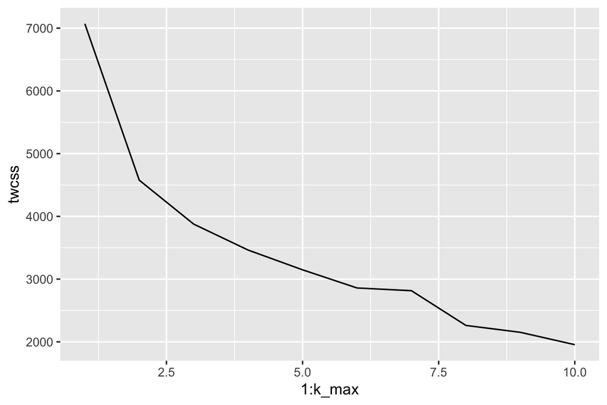

```r
set.seed(123) #this function prevents k-means from randomly assigning the initial cluster centers
k_max <- 10 #let the maximum amount of clusters be 10
twcss <- sapply(1:k_max, function(k){kmeans(Boston2, k)$tot.withinss}) #calculating the total sum of squares
library(ggplot2)
qplot(x = 1:k_max, y = twcss, geom = 'line') #visualizing the clusters
```

The total WCSS changes radically around 2, which means **2 is an optimal number of clusters.**  
Lets run the code again and plot it:

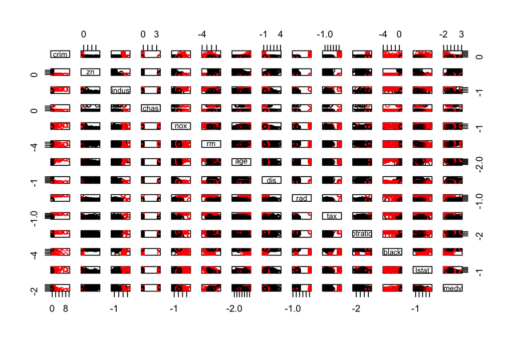

```r
km <-kmeans(Boston2, centers = 2)
pairs(Boston2, col = km$cluster)
```